# EDA

```r
PlayList <- read.csv("PlayList.csv")
InjuryRecord <- read.csv("InjuryRecord.csv")
library(tidyverse)
library(ggplot2)
```

```r
glimpse(PlayList)
```

```
Rows: 267,005
Columns: 14
$ PlayerKey      <int> 26624, 26624, 26624, 26624, 26624, 26624, 26624, 26624, 26624, 26…
$ GameID         <chr> "26624-1", "26624-1", "26624-1", "26624-1", "26624-1", "26624-1",…
$ PlayKey        <chr> "26624-1-1", "26624-1-2", "26624-1-3", "26624-1-4", "26624-1-5", …
$ RosterPosition <chr> "Quarterback", "Quarterback", "Quarterback", "Quarterback", "Quar…
$ PlayerDay      <int> 1, 1, 1, 1, 1, 1, 1, 1, 1, 1, 1, 1, 1, 1, 1, 1, 1, 1, 1, 1, 1, 1,…
$ PlayerGame     <int> 1, 1, 1, 1, 1, 1, 1, 1, 1, 1, 1, 1, 1, 1, 1, 1, 1, 1, 1, 1, 1, 1,…
$ StadiumType    <chr> "Outdoor", "Outdoor", "Outdoor", "Outdoor", "Outdoor", "Outdoor",…
$ FieldType      <chr> "Synthetic", "Synthetic", "Synthetic", "Synthetic", "Synthetic", …
$ Temperature    <int> 63, 63, 63, 63, 63, 63, 63, 63, 63, 63, 63, 63, 63, 63, 63, 63, 6…
$ Weather        <chr> "Clear and warm", "Clear and warm", "Clear and warm", "Clear and …
$ PlayType       <chr> "Pass", "Pass", "Rush", "Rush", "Pass", "Rush", "Pass", "Pass", "…
$ PlayerGamePlay <int> 1, 2, 3, 4, 5, 6, 7, 8, 9, 10, 11, 12, 13, 14, 15, 16, 17, 18, 19…
$ Position       <chr> "QB", "QB", "QB", "QB", "QB", "QB", "QB", "QB", "QB", "QB", "QB",…
$ PositionGroup  <chr> "QB", "QB", "QB", "QB", "QB", "QB", "QB", "QB", "QB", "QB", "QB",…
```

```r
summary(PlayList)
```

```
   PlayerKey        GameID            PlayKey          RosterPosition       PlayerDay
 Min.   :26624   Length:267005      Length:267005      Length:267005      Min.   :-62.0
 1st Qu.:39653   Class :character   Class :character   Class :character   1st Qu.: 43.0
 Median :42432   Mode  :character   Mode  :character   Mode  :character   Median :102.0
 Mean   :41515                                                            Mean   :210.5
 3rd Qu.:44480                                                            3rd Qu.:400.0
 Max.   :47888                                                            Max.   :480.0
   PlayerGame   StadiumType         FieldType          Temperature        Weather
 Min.   : 1.0   Length:267005      Length:267005      Min.   :-999.00   Length:267005
 1st Qu.: 7.0   Class :character   Class :character   1st Qu.:  44.00   Class :character
 Median :13.0   Mode  :character   Mode  :character   Median :  61.00   Mode  :character
 Mean   :13.8                                         Mean   : -35.03
 3rd Qu.:20.0                                         3rd Qu.:  72.00
 Max.   :32.0                                         Max.   :  97.00
   PlayType         PlayerGamePlay     Position         PositionGroup
 Length:267005      Min.   :  1.00   Length:267005      Length:267005
 Class :character   1st Qu.: 13.00   Class :character   Class :character
 Mode  :character   Median : 26.00   Mode  :character   Mode  :character
                    Mean   : 29.06
                    3rd Qu.: 43.00
                    Max.   :102.00
```

```r
colnames(PlayList)
```

```
 [1] "PlayerKey"      "GameID"         "PlayKey"        "RosterPosition" "PlayerDay"
 [6] "PlayerGame"     "StadiumType"    "FieldType"      "Temperature"    "Weather"
[11] "PlayType"       "PlayerGamePlay" "Position"       "PositionGroup"
```

This is the detailed summary of the various variables within the data set and their classification type. Below is a more detailed description of each variable…

PlayerKey: Player Identification number to be used instead of name

PlayerGame: The number of games the player had played in till the injury

PlayType: Description of the various types of plays that are possible in the NFL. These include passing downs as well as rushing downs.

GameID: Game identification number

StadiumType: Description of the structure of the stadium the player played at.

PlayKey: Play identification number to reference specific type of play that occured.

FieldType: Surface of the field ranging from synthetic turf to natural grass.

Position: Identifies the roster position of the player.

RosterPosition: Identifies the roster position of the player.

Temperature: Indicates the temperature at the time of play during the specific game.

PositionGroup: Identifies the roster position of the player.

PlayerDay: The days since the start of the season for the specific player.

Weather: Descriptions of the weather conditions during the specific game and time of play.

```r
summary(as.factor(PlayList$RosterPosition))
```

```
       Cornerback Defensive Lineman            Kicker        Linebacker Offensive Lineman
            28987             30588               708             50129             47413
      Quarterback      Running Back            Safety         Tight End     Wide Receiver
             6986             11664             39387              7752             43391
```

```r
summary(as.factor(PlayList$StadiumType))
```

```
                                         Bowl            Closed Dome
                 16910                    465                   1011
                Cloudy                   Dome           Dome, closed
                   178                   9376                   1059
                 Domed          Domed, closed            Domed, open
                   985                   3076                   1779
           Domed, Open            Heinz Field                 Indoor
                   807                    389                   6892
     Indoor, Open Roof    Indoor, Roof Closed                Indoors
                   479                    547                  22805
                  Open                 Oudoor                Ourdoor
                  4124                    914                    778
              Outddors                Outdoor Outdoor Retr Roof-Open
                   595                 145032                    601
              Outdoors                 Outdor                Outside
                 32956                    356                    341
   Retr. Roof - Closed      Retr. Roof - Open      Retr. Roof Closed
                  2235                    486                    414
     Retr. Roof-Closed        Retr. Roof-Open       Retractable Roof
                  2015                    486                   8914
```

```r
summary(as.factor(PlayList$FieldType))
```

```
  Natural Synthetic
   156902    110103
```

```r
summary(as.factor(PlayList$Weather))
```

```
                                                                           18691
                                                              10% Chance of Rain
                                                                             413
                                                              30% Chance of Rain
                                                                             354
                                                                           Clear
                                                                           25923
                                                                  Clear and cold
                                                                             758
                                                                  Clear and Cool
                                                                             638
                                                                 Clear and sunny
                                                                             488
                                                                 Clear and Sunny
                                                                             613
                                                                  Clear and warm
                                                                            1252
                                                                     Clear skies
                                                                             812
                                                                     Clear Skies
                                                                             842
                                                          Clear to Partly Cloudy
                                                                             495
                                                                          cloudy
                                                                             987
                                                                          Cloudy
                                                                           60705
                                                                 Cloudy and cold
                                                                             745
                                                                 Cloudy and Cool
                                                                             835
Cloudy with periods of rain, thunder possible. Winds shifting to WNW, 10-20 mph.
                                                                             246
                                                      Cloudy, 50% change of rain
                                                                             769
                                                          Cloudy, chance of rain
                                                                             456
                                   Cloudy, fog started developing in 2nd quarter
                                                                             766
                                            Cloudy, light snow accumulating 1-3"
```

[output cut: 72 more lines]

```
                                                                             385
                                                                           Sunny
                                                                           51728
                                                                 Sunny and clear
                                                                             698
                                                                  Sunny and cold
                                                                             535
                                                                  Sunny and warm
                                                                             687
                                                                     Sunny Skies
                                                                             618
                                                       Sunny, highs to upper 80s
                                                                             632
                                                                    Sunny, Windy
                                                                             467
```

```r
summary(as.factor(PlayList$PlayType))
```

```
                                        0          Extra Point           Field Goal
                 367                  279                 5906                 4915
             Kickoff Kickoff Not Returned     Kickoff Returned                 Pass
                5754                 4625                 2773               138079
                Punt    Punt Not Returned        Punt Returned                 Rush
                5746                 3486                 2469                92606
```

```r
summary(as.factor(PlayList$Position))
```

```
           C           CB           DB           DE           DT           FS            G
       12963        29584         1280        13800        14119        21373        17467
          HB          ILB            K           LB Missing Data          MLB           NT
         230         8359          538         2727           45         5595         2587
         OLB            P           QB           RB            S           SS            T
       33524          170         6969        11359          471        15660        16979
          TE           WR
        7749        43457
```

```r
summary(as.factor(PlayList$PositionGroup))
```

```
          DB           DL           LB Missing Data           OL           QB           RB
       68295        29830        50954           45        47409         6969        11659
        SPEC           TE           WR
         708         7749        43387
```

Shows the number of each category that exists within the PlayList dataset.

```r
glimpse(InjuryRecord)
```

```
Rows: 105
Columns: 9
$ PlayerKey <int> 39873, 46074, 36557, 46646, 43532, 41145, 46014, 44860, 44806, 45962, …
$ GameID    <chr> "39873-4", "46074-7", "36557-1", "46646-3", "43532-5", "41145-2", "460…
$ PlayKey   <chr> "39873-4-32", "46074-7-26", "36557-1-70", "46646-3-30", "43532-5-69", …
$ BodyPart  <chr> "Knee", "Knee", "Ankle", "Ankle", "Ankle", "Knee", "Ankle", "Knee", "K…
$ Surface   <chr> "Synthetic", "Natural", "Synthetic", "Natural", "Synthetic", "Natural"…
$ DM_M1     <int> 1, 1, 1, 1, 1, 1, 1, 1, 1, 1, 1, 1, 1, 1, 1, 1, 1, 1, 1, 1, 1, 1, 1, 1…
$ DM_M7     <int> 1, 1, 1, 0, 1, 0, 1, 1, 0, 1, 1, 1, 1, 1, 1, 0, 1, 1, 1, 1, 1, 1, 1, 1…
$ DM_M28    <int> 1, 0, 1, 0, 1, 0, 1, 0, 0, 0, 1, 1, 1, 1, 1, 0, 0, 1, 0, 1, 1, 0, 1, 1…
$ DM_M42    <int> 1, 0, 1, 0, 1, 0, 1, 0, 0, 0, 1, 1, 1, 1, 1, 0, 0, 1, 0, 1, 1, 0, 1, 1…
```

```r
summary(InjuryRecord)
```

```
   PlayerKey        GameID            PlayKey            BodyPart
 Min.   :31070   Length:105         Length:105         Length:105
 1st Qu.:39656   Class :character   Class :character   Class :character
 Median :43518   Mode  :character   Mode  :character   Mode  :character
 Mean   :42284
 3rd Qu.:45966
 Max.   :47813
   Surface              DM_M1       DM_M7            DM_M28           DM_M42
 Length:105         Min.   :1   Min.   :0.0000   Min.   :0.0000   Min.   :0.0000
 Class :character   1st Qu.:1   1st Qu.:0.0000   1st Qu.:0.0000   1st Qu.:0.0000
 Mode  :character   Median :1   Median :1.0000   Median :0.0000   Median :0.0000
                    Mean   :1   Mean   :0.7238   Mean   :0.3524   Mean   :0.2762
                    3rd Qu.:1   3rd Qu.:1.0000   3rd Qu.:1.0000   3rd Qu.:1.0000
                    Max.   :1   Max.   :1.0000   Max.   :1.0000   Max.   :1.0000
```

```r
colnames(InjuryRecord)
```

```
[1] "PlayerKey" "GameID"    "PlayKey"   "BodyPart"  "Surface"   "DM_M1"     "DM_M7"
[8] "DM_M28"    "DM_M42"
```

```r
summary(as.factor(InjuryRecord$BodyPart))
```

```
Ankle  Foot  Heel  Knee  Toes
   42     7     1    48     7
```

```r
summary(as.factor(InjuryRecord$Surface))
```

```
  Natural Synthetic
       48        57
```

Shows that the most lower body injuries occured at the Knee and most lower body injuries occured on synthetic field surfaces.

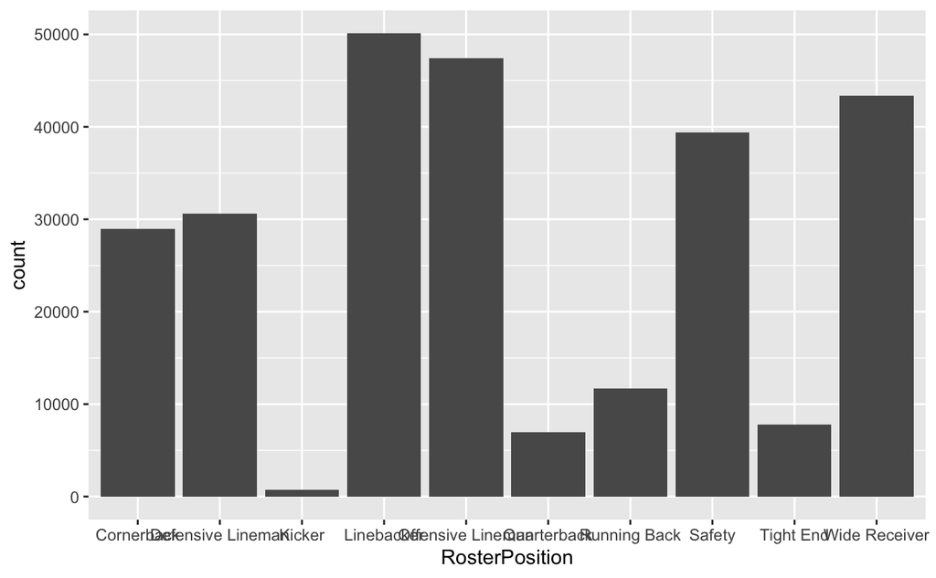

```r
#bar chart
ggplot(data = nflData) +
  geom_bar(mapping = aes(x = RosterPosition))
```

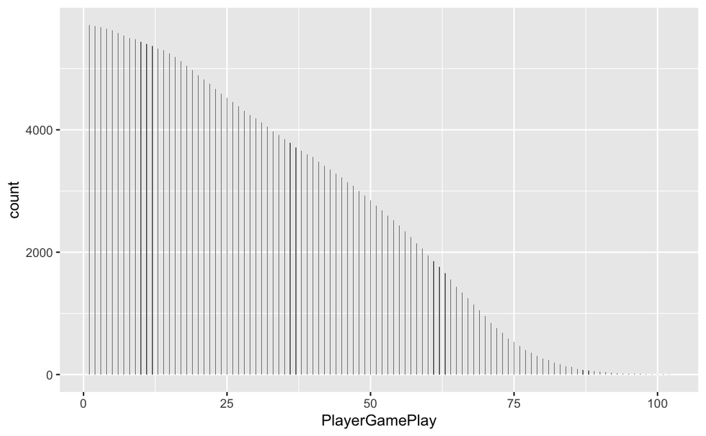

```r
# histogram
nflData %>% #pipeline expression
  ggplot() +
  geom_histogram(mapping = aes(x = PlayerGamePlay), binwidth = 0.1)
```

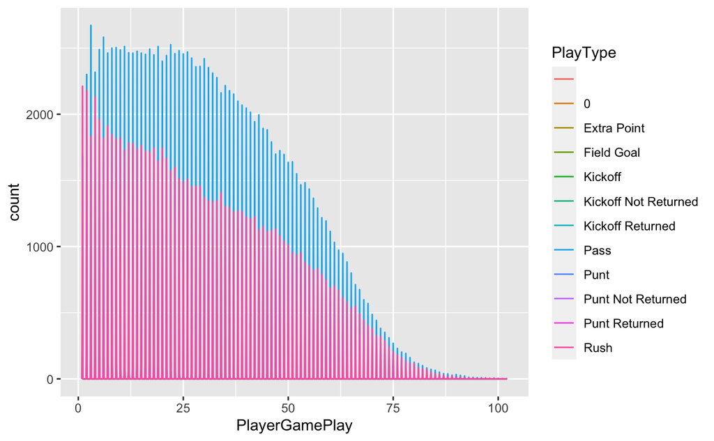

```r
nflData %>%
  ggplot(mapping = aes(x = PlayerGamePlay, colour = PlayType)) +
  geom_freqpoly(binwidth = 0.1)
```

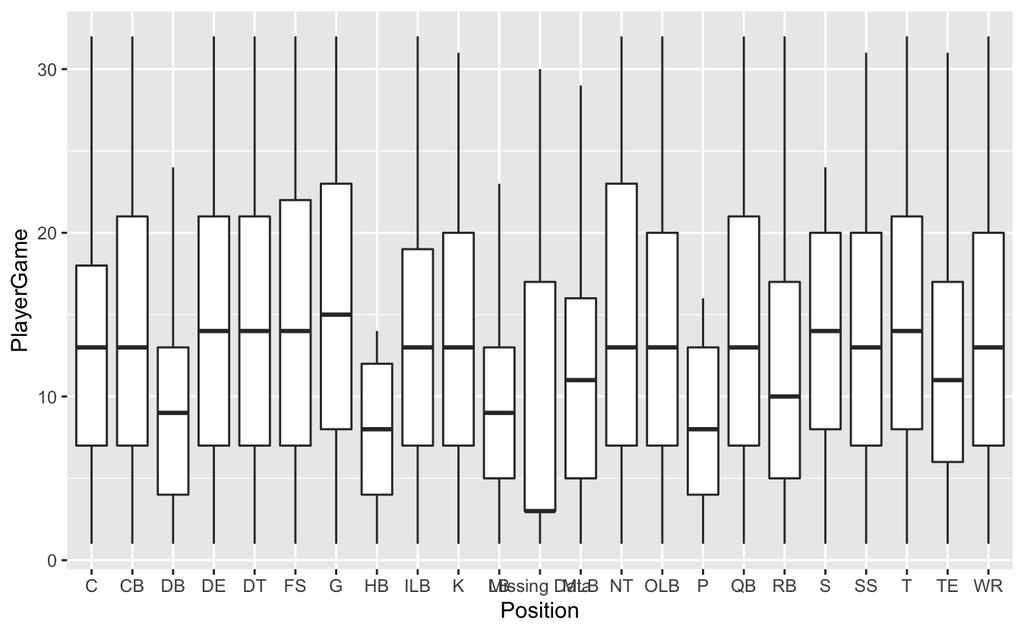

```r
# boxplot (one categorical + one numerical variable)
nflData %>%
  ggplot(mapping = aes(x = Position, y = PlayerGame)) +
  geom_boxplot()
```

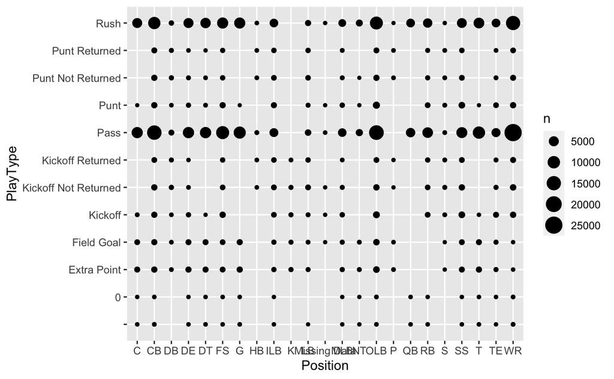

```r
# two categorical variables
nflData %>%
  ggplot() +
  geom_count(mapping = aes(x = Position, y = PlayType))
```

Now for the analysis of lower body injuries from the Injury Record data set.

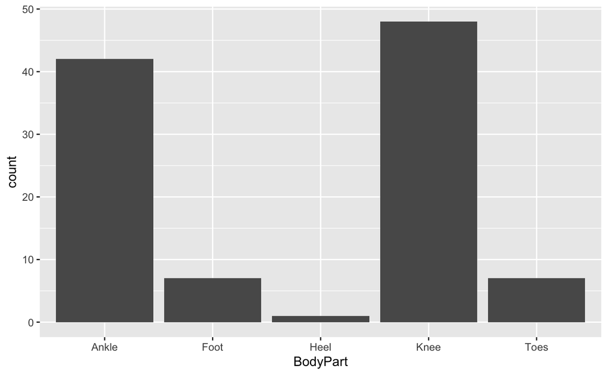

```r
ggplot(data = InjuryRecord) +
  geom_bar(mapping = aes(x = BodyPart))
```

Evidently, the knee seems to be at high risk of injury according to injury records, whereas the heel seems to have the lowest risk of injury.

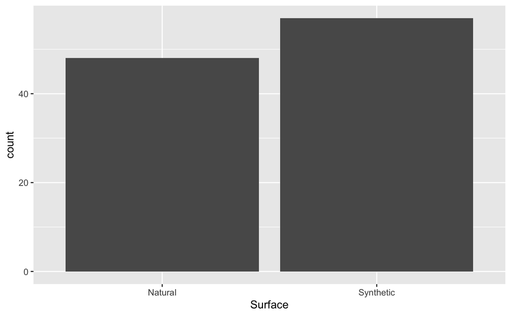

```r
ggplot(data = InjuryRecord) +
  geom_bar(mapping = aes(x = Surface))
```

More injuries occured on synthetic field surfaces.